# NLP Research

### Position: Research Internship

### Name:

Please answer the following questions and save your notebook in html and send it by 11-04-2019 EOD.

We are going to create NER system using LSTM seq to seq architecture.

In this exercise, we will help you to think through the process of creating and evaluating this simple NER prediction engine. You will have to work through the steps indicated below and evaluate the performance of the system.

### SUBMITTED By-SHAMBHURAJ BARGE

### ST.ID-2579

## Prerequest libraries

```python
# Import the necessary libraries, modules
import pandas as pd
import numpy as np
from keras.layers import Dense, SimpleRNN, GRU, LSTM, Embedding # Import layers from Keras
from keras.models import Sequential
from keras.layers import SimpleRNN, Embedding, Dense, LSTM
from keras.models import Sequential
from keras.layers import Dense, Dropout, Flatten, BatchNormalization, regularizers


from keras.preprocessing.text import Tokenizer
from keras.preprocessing.sequence import pad_sequences
import pandas as pd
import numpy as np
from sklearn.feature_extraction import DictVectorizer
from sklearn.feature_extraction.text import HashingVectorizer
from sklearn.linear_model import Perceptron
from sklearn.model_selection import train_test_split
from sklearn.linear_model import SGDClassifier
from sklearn.linear_model import PassiveAggressiveClassifier
from sklearn.naive_bayes import MultinomialNB
from sklearn.metrics import classification_report
from imblearn.metrics import classification_report_imbalanced
from sklearn.metrics import precision_score, recall_score, f1_score, roc_auc_score, accuracy_score, classification_report

import tensorflow as tf
```

# 1. Please find the attached Ner_dataset. Read the file. "Tag" is the target.

## Reading the data

```python
raw_train_data = pd.read_csv('ner_dataset.csv', encoding='latin-1') # Read the data as a DataFrame using Pandas


print(raw_train_data.shape) # Print the dimensions of train DataFrame
print('\n')
raw_train_data.head(5) # Print the top few records
```

```
(1048575, 4)
```

|  | Sentence # | Word | POS | Tag |
| --- | --- | --- | --- | --- |
| 0 | Sentence: 1 | Thousands | NNS | O |
| 1 | NaN | of | IN | O |
| 2 | NaN | demonstrators | NNS | O |
| 3 | NaN | have | VBP | O |
| 4 | NaN | marched | VBN | O |

### observation:-

#### our target column is Tag and input is word

# 2. Look at the data and write about your understanding of the data.

## checking null values

```python
raw_train_data.isnull().sum()
```

```
Sentence #    1000616
Word                0
POS                 0
Tag                 0
dtype: int64
```

### observation:- very high null values in sentence # column

## Imputation of null values with previous string seq

```python
raw_train_data= raw_train_data.fillna(method='ffill')

raw_train_data['Sentence #'].nunique(), raw_train_data.Word.nunique(), raw_train_data.Tag.nunique()
```

```
(47959, 35178, 17)
```

```python
raw_train_data.isnull().sum()
```

```
Sentence #    0
Word          0
POS           0
Tag           0
dtype: int64
```

## data size

```python
print(raw_train_data.shape)
```

```
(1048575, 4)
```

```python
raw_train_data.head(10)
```

|  | Sentence # | Word | POS | Tag |
| --- | --- | --- | --- | --- |
| 0 | Sentence: 1 | Thousands | NNS | O |
| 1 | Sentence: 1 | of | IN | O |
| 2 | Sentence: 1 | demonstrators | NNS | O |
| 3 | Sentence: 1 | have | VBP | O |
| 4 | Sentence: 1 | marched | VBN | O |
| 5 | Sentence: 1 | through | IN | O |
| 6 | Sentence: 1 | London | NNP | B-geo |
| 7 | Sentence: 1 | to | TO | O |
| 8 | Sentence: 1 | protest | VB | O |
| 9 | Sentence: 1 | the | DT | O |

### Observation:

Named entity recognition (NER)is probably the first step towards information extraction that seeks to locate and classify named entities in text into pre-defined categories such as the names of persons, organizations, locations, expressions of times, quantities, monetary values, percentages, etc. NER is used in many fields in Natural Language Processing (NLP), and it can help answering many real-world questions, such as:

Which companies were mentioned in the news articles?,Does the tweet contain the name of a person ?, what are the product complaints or reviews?,finding persons location on his tweet Were specified products mentioned in complaints or reviews?

### Check target frequency

```python
pd.value_counts(raw_train_data['Tag'])
```

```
O        887908
B-geo     37644
B-tim     20333
B-org     20143
I-per     17251
B-per     16990
I-org     16784
B-gpe     15870
I-geo      7414
I-tim      6528
B-art       402
B-eve       308
I-art       297
I-eve       253
B-nat       201
I-gpe       198
I-nat        51
Name: Tag, dtype: int64
```

### observation:-

total 17 targets and data is unbalanced

- according to me #### 1) O means= other #### 2) geo = Geographical Entity #### 3) org = Organization #### 4) per = Person #### 5) gpe = Geopolitical Entity #### 6) tim = Time indicator #### 7) art = Artifact #### 8) eve = Event #### 9) nat = Natural Phenomenon

```python
train.shape
```

```
(734002, 2)
```

```python
test.shape
```

```
(314573, 2)
```

# 3.Do all the necessary pre processing steps to build an Lstm architecture.

Ex: Tokenizations, padding, train-test split etc

### Converting unstructured text to structured numeric form

This includes:

1. Tokenizing
2. Converting sequence of words to sequence of word indeces
3. Converting varing length sequences to fixed length sequences through padding

```python
len(raw_data.Word)
```

```
1048575
```

## Tokenization

define some parameter that we need further

```python
from keras.preprocessing.text import Tokenizer
from keras.preprocessing.sequence import pad_sequences

tokenizer = Tokenizer(num_words=5000, lower=True)
tokenizer.fit_on_texts(raw_data.Word)
sequences = tokenizer.texts_to_sequences(raw_data.Word)
x = pad_sequences(sequences, maxlen=180)
```

```python
x
```

```
array([[  0,   0,   0, ...,   0,   0, 260],
       [  0,   0,   0, ...,   0,   0,   3],
       [  0,   0,   0, ...,   0,   0, 997],
       ...,
       [  0,   0,   0, ...,   0,   0,   4],
       [  0,   0,   0, ...,   0,   0,   1],
       [  0,   0,   0, ...,   0,   0, 120]])
```

```python
unique_labels = list(train.Tag.unique())
print(unique_labels)
```

```
['O', 'B-org', 'B-tim', 'I-org', 'B-per', 'B-geo', 'I-tim', 'B-gpe', 'I-per', 'I-geo', 'I-eve', 'B-eve', 'I-gpe', 'I-art', 'B-art', 'B-nat', 'I-nat']
```

```python
from keras.utils import to_categorical # This convers the labels to one-hot vectors(Dummies)
b= np.array([unique_labels.index(i) for i in raw_data.Tag]) # Convert the word labels to indeces
y = to_categorical(b) # Du
```

# 4. Create Train-Test split

## train test split

```python
from sklearn.model_selection import train_test_split

x_train, x_test, y_train, y_test = train_test_split(x, y, test_size=0.3, random_state=9000)
```

## 5. Build an LSTM architecture with dropout and batch normilization layers

## Building and training an LSTM model

```python
from keras.models import Sequential
from keras.layers import Dense, Embedding, GlobalMaxPool1D, Dropout
from keras.optimizers import Adam

model = Sequential()
# embedding layer
model.add(Embedding(5000, 20, input_length=180))
model.add(Dropout(0.15))
# lstm layer
model.add(LSTM(20, return_sequences=False))
model.add(BatchNormalization())
model.add(Dropout(0.4))

# o/p layer-1
model.add(Dense(17, activation='softmax'))
```

## Model summary

```python
model.summary()
```

```
_________________________________________________________________
Layer (type)                 Output Shape              Param #
=================================================================
embedding_12 (Embedding)     (None, 180, 20)           100000
_________________________________________________________________
dropout_22 (Dropout)         (None, 180, 20)           0
_________________________________________________________________
lstm_16 (LSTM)               (None, 20)                3280
_________________________________________________________________
batch_normalization_13 (Batc (None, 20)                80
_________________________________________________________________
dropout_23 (Dropout)         (None, 20)                0
_________________________________________________________________
dense_9 (Dense)              (None, 17)                357
=================================================================
Total params: 103,717
Trainable params: 103,677
Non-trainable params: 40
_________________________________________________________________
```

## model compile

```python
model.compile(optimizer=Adam(0.015), loss='categorical_crossentropy', metrics=['accuracy'])
```

## build the model

```python
history = model.fit(x_train, y_train,
                    epochs=3,
                    batch_size=512,
                    validation_split=0.1
                    )
```

```
Train on 660601 samples, validate on 73401 samples
```

## Plotting the results

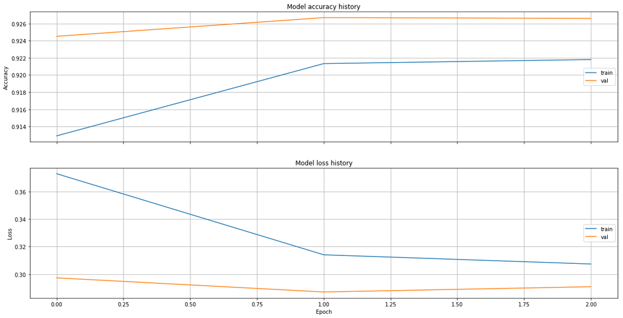

```python
fig, ax = plt.subplots(2, 1, sharex='col', figsize=(20, 10))
ax[0].set_title('Model accuracy history')
ax[0].plot(history.history['acc'])
ax[0].plot(history.history['val_acc'])
ax[0].set_ylabel('Accuracy')
ax[0].legend(['train', 'val'], loc='right')
ax[0].grid()

ax[1].set_title('Model loss history')
ax[1].plot(history.history['loss'])
ax[1].plot(history.history['val_loss'])
ax[1].set_ylabel('Loss')
ax[1].legend(['train', 'val'], loc='right')
ax[1].grid()
plt.xlabel('Epoch')
plt.show()
```

### observation:- as it takes more time to run an epochs hence we have built simple model with only one lstm layer

### that's why val accuracy shows more than training and loss also least